# Peer Assessment II

# 1 Background

As a statistical consultant working for a real estate investment firm, your task is to develop a model to predict the selling price of a given home in Ames, Iowa. Your employer hopes to use this information to help assess whether the asking price of a house is higher or lower than the true value of the house. If the home is undervalued, it may be a good investment for the firm.

# 2 Training Data and relevant packages

In order to better assess the quality of the model you will produce, the data have been randomly divided into three separate pieces: a training data set, a testing data set, and a validation data set. For now we will load the training data set, the others will be loaded and used later.

Use the code block below to load any necessary packages

## 2.1 Part 1 - Exploratory Data Analysis (EDA)

When you first get your data, it’s very tempting to immediately begin fitting models and assessing how they perform. However, before you begin modeling, it’s absolutely essential to explore the structure of the data and the relationships between the variables in the data set.

Do a detailed EDA of the ames_train data set, to learn about the structure of the data and the relationships between the variables in the data set (refer to Introduction to Probability and Data, Week 2, for a reminder about EDA if needed). Your EDA should involve creating and reviewing many plots/graphs and considering the patterns and relationships you see.

After you have explored completely, submit the three graphs/plots that you found most informative during your EDA process, and briefly explain what you learned from each (why you found each informative).

The exploratory data analysis provided a view into its structure, shape, correlations, associations and outliers. Of particular interest were the relative importance of features, the value of the interactions between the variables, and the correlations among the predictors. Here are a few key insights.

### 2.1.1 Relative Importance of Terms

As indicated in Figure 1, overall quality, neighborhood and size were among the most important features. In fact, independent simple linear regressions showed that the variation in each of those variables independently accounted for over 50% of the variation in the log price.

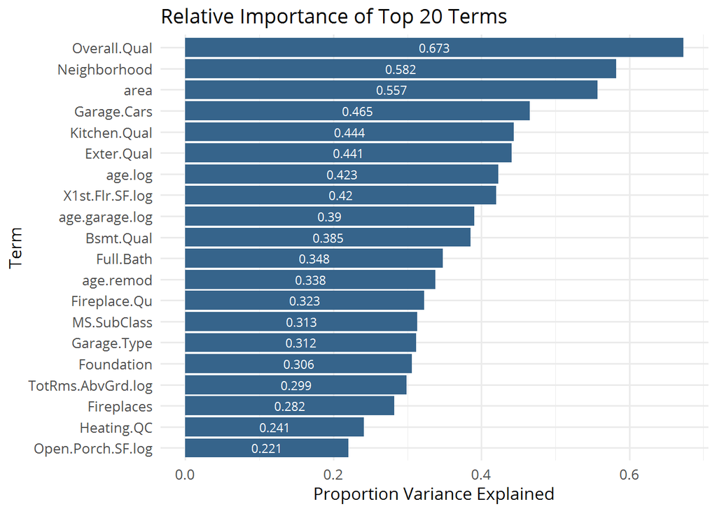

Figure 1: Relative Importance of Terms

### 2.1.2 Relative Importance of Interaction Terms

Whereas individual terms accounted for up to 67% of variance explained in the log price, the interaction terms had a more pronounced effect on the response. The top 10 interaction terms shown in Figure 2 accounted for up to 80% of variance explained in the log price.

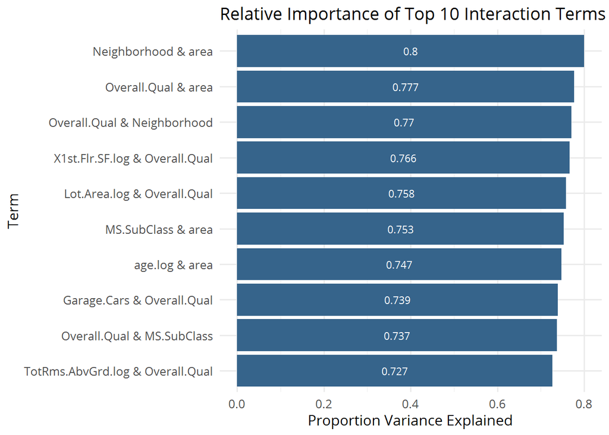

Figure 2: Relative Importance of Interaction Terms

#### 2.1.2.1 Correlation Analysis

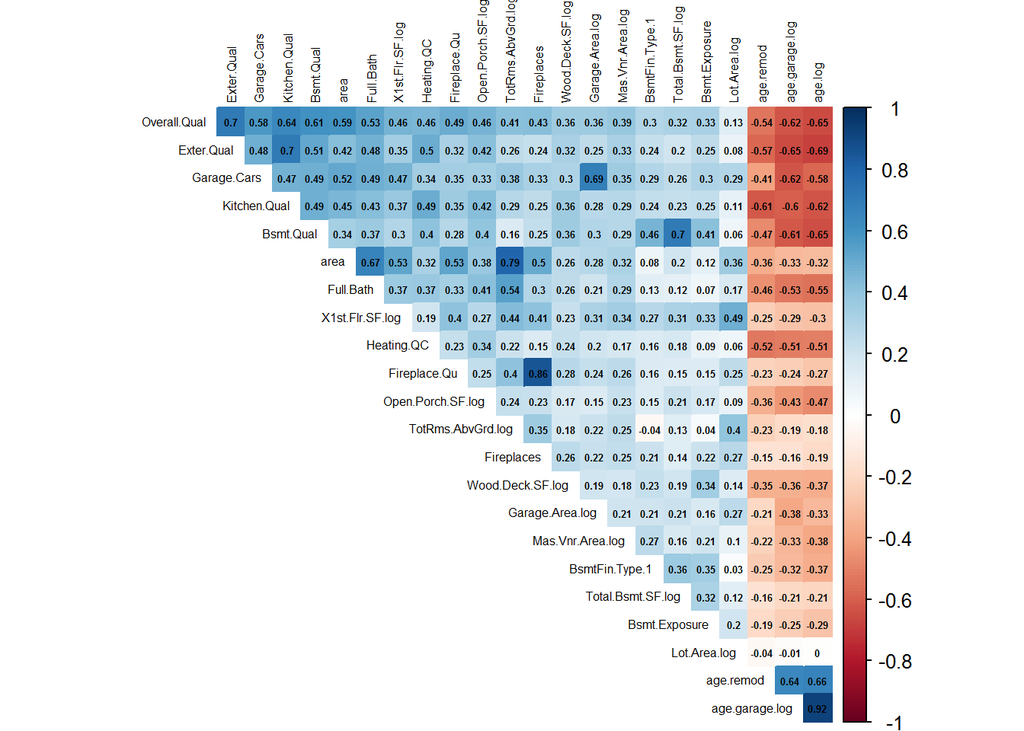

Figure 3: Correlation Plot

## 2.2 Part 2 - Development and assessment of an initial model, following a semi-guided process of analysis

### 2.2.1 Section 2.1 An Initial Model

In building a model, it is often useful to start by creating a simple, intuitive initial model based on the results of the exploratory data analysis. (Note: The goal at this stage is **not** to identify the “best” possible model but rather to choose a reasonable and understandable starting point. Later you will expand and revise this model to create your final model.

Based on your EDA, select *at most* 10 predictor variables from “ames_train” and create a linear model for `price` (or a transformed version of price) using those variables. Provide the *R code* and the *summary output table* for your model, a *brief justification* for the variables you have chosen, and a *brief discussion* of the model results in context (focused on the variables that appear to be important predictors and how they relate to sales price).

For this base model, we’ll start with a most parsimonious containing just the 3 most important variables. We will use this as a benchmark against which we will compare more complex models. The code snippet in Figure 4 creates the linear model including overall quality, the neighborhood and the area.

```r
target <- "price.log"

# Creates a simple linear regression from the top 10 variables from relative importance computed above (not shown)
alphaFmla <- as.formula(paste(target, paste(ri$term[1:3], collapse = "+"),
    sep = "~"))
alpha <- lm(alphaFmla, data = df)
alphaPred <<- predict(alpha, data = df)
alphaSummary <- tidy(alpha)
alphaStats <- glance(alpha)
alphaR2 <- alphaStats$adj.r.squared
alphaRMSE <- sqrt(mean((exp(df$price.log) - exp(alphaPred))^2))
```

Figure 4: Model Alpha

As shown in Table 1, this initial model accounts for approximately 85 percent of the variation in log price in the training set. That’s a reasonably good result, given that there are just three variables in the regression equation.

Table 1: Model Alpha Regression Summary Statistics

|  | r.squared | adj.r.squared | sigma | statistic | p.value | df | logLik | AIC | BIC | deviance | df.residual |
| --- | --- | --- | --- | --- | --- | --- | --- | --- | --- | --- | --- |
| value | 0.8577 | 0.8533 | 0.1463 | 194.84 | 0 | 26 | 433.0666 | -812.1333 | -684.525 | 17.2848 | 808 |

Table 2 outlines the model coefficient estimates, standard error, the statistic and the p-values for the linear model.

Table 2: Model Alpha Coefficient Estimates

| term | estimate | std.error | statistic | p.value |
| --- | --- | --- | --- | --- |
| (Intercept) | 10.8920 | 0.0688 | 158.3807 | 0.0000 |
| Overall.Qual | 0.1160 | 0.0062 | 18.5799 | 0.0000 |
| NeighborhoodOther | -0.0356 | 0.0686 | -0.5179 | 0.6047 |
| NeighborhoodBrDale | -0.3749 | 0.0787 | -4.7641 | 0.0000 |
| NeighborhoodBrkSide | -0.1927 | 0.0615 | -3.1320 | 0.0018 |
| NeighborhoodClearCr | 0.0935 | 0.0716 | 1.3067 | 0.1917 |
| NeighborhoodCollgCr | 0.0265 | 0.0580 | 0.4571 | 0.6477 |
| NeighborhoodCrawfor | -0.0086 | 0.0632 | -0.1362 | 0.8917 |
| NeighborhoodEdwards | -0.1564 | 0.0604 | -2.5877 | 0.0098 |
| NeighborhoodGilbert | -0.0020 | 0.0607 | -0.0328 | 0.9738 |
| NeighborhoodIDOTRR | -0.3007 | 0.0636 | -4.7278 | 0.0000 |
| NeighborhoodMeadowV | -0.3161 | 0.0682 | -4.6333 | 0.0000 |
| NeighborhoodMitchel | 0.0538 | 0.0605 | 0.8888 | 0.3744 |
| NeighborhoodNAmes | -0.0270 | 0.0578 | -0.4663 | 0.6411 |
| NeighborhoodNoRidge | 0.0741 | 0.0627 | 1.1807 | 0.2381 |
| NeighborhoodNridgHt | 0.1600 | 0.0608 | 2.6325 | 0.0086 |
| NeighborhoodNWAmes | -0.0181 | 0.0613 | -0.2948 | 0.7682 |
| NeighborhoodOldTown | -0.2714 | 0.0598 | -4.5401 | 0.0000 |
| NeighborhoodSawyer | -0.0346 | 0.0598 | -0.5785 | 0.5631 |
| NeighborhoodSawyerW | -0.0732 | 0.0605 | -1.2086 | 0.2272 |
| NeighborhoodSomerst | 0.0435 | 0.0595 | 0.7322 | 0.4642 |
| NeighborhoodStoneBr | 0.0818 | 0.0698 | 1.1725 | 0.2413 |
| NeighborhoodSWISU | -0.2799 | 0.0727 | -3.8487 | 0.0001 |
| NeighborhoodTimber | 0.1415 | 0.0657 | 2.1517 | 0.0317 |
| NeighborhoodVeenker | 0.1485 | 0.0738 | 2.0116 | 0.0446 |
| area | 0.0003 | 0.0000 | 22.4539 | 0.0000 |

```r
RSS <- c(crossprod(alpha$residuals))
MSE <- RSS/length(alpha$residuals)
yBar <- exp(alphaSummary$estimate[1] + 1/2 * MSE)
```

Figure 6: Intercept Back-transformation

Hence, Figure 6 shows an intercept value of 10.89 on the log price scale which corresponds to an expected mean of 54,306.37 dollars. Likewise, the coefficients must be back-transformed to have a clear interpretation of their effects on price.

```r
effects <- rbindlist(lapply(seq_along(1:nrow(alphaSummary)),
    function(i) {
        efx <- list()
        efx$term <- alphaSummary$term[i]
        if (i == 1) {
            efx$increase <- "NA"
            efx$pct_change <- 0
        } else if (i %in% c(30, 31, 32)) {
            efx$increase <- "One Percent"
            efx$pct_change <- 100 * (1.01^alphaSummary$estimate[i] -
                1)
        } else {
            efx$increase <- "One Unit"
            efx$pct_change <- 100 * (exp(alphaSummary$estimate[i]) -
                1)
        }
        efx
    }))
```

Figure 7: Coefficient Back-transformation

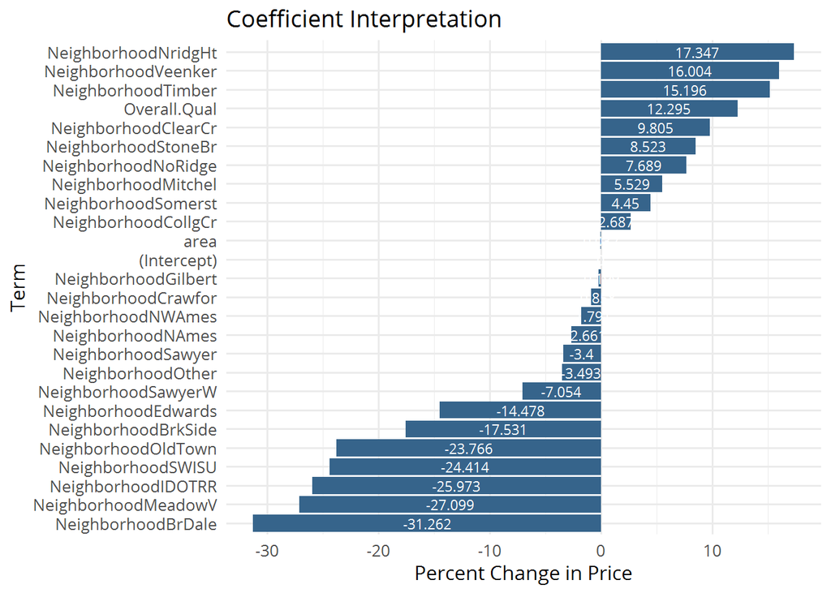

Figure 8: Coefficient Interpretation

Now we can interpret the intercept and coefficients on the linear scale. From Figure 8, location seems have the strongest effect, both positive and negative, on price. Clearly some neighborhoods can command higher prices, than can others. Overall quality is also a strong indicator; however, it is worth noting that area has a nearly imperceptible effect on price, within the context of overall quality and location.

### 2.2.2 Section 2.2 Model Selection

Now either using `BAS` another step-wise selection procedure choose the “best” model you can, using your initial model as your starting point. Try at least two different model selection methods and compare their results. Do they both arrive at the same model or do they disagree? What do you think this means?

#### 2.2.2.1 Model Performance Summary

Having started with the three predictor model, we’ll create a model containing the 10 most important features as determined by the percentage of variance in log price explained by each variable. Prior to model fitting, we’ll remove variables which are highly correlated with more important variables. Once the data is prepared, we’ll create four different models using the following four selection techniques:  
1. Bayes Model Averaging including predictions for highest probability and best predictive models  
2. Step-wise Forward Selection  
3. Step-wise Backward Elimination  
4. Step-wise Bidirectional Selection / Elimination

Models were fit, predictions calculated and the adjusted $R2$ and in-sample RMSE metrics were computed.

[figure not shown]

Figure 9: Model Predictive Performance

The models had nearly identical adjusted $R^2$ scores. Next, we’ll take a closer look at the coefficients.

#### 2.2.2.2 Model Coefficient Summary

The coefficient estimates for the each variable selection method are shown in Table 3.

Table 3: Model Coefficient Summary

| Term | HPM | Forward | Backward | Bidirectional |
| --- | --- | --- | --- | --- |
| Intercept | 11.9958 | 9.6050 | 9.6108 | 9.6108 |
| age.log | -0.0415 | -0.0730 | -0.0651 | -0.0651 |
| area | 0.0002 | 0.0003 | 0.0003 | 0.0003 |
| Bsmt.Qual | 0.0507 | 0.0496 | 0.0495 | 0.0495 |
| Garage.Cars | 0.0370 | 0.0360 | 0.0347 | 0.0347 |
| Kitchen.Qual | 0.0733 | 0.0712 | 0.0711 | 0.0711 |
| NeighborhoodBrDale | -0.1899 | -0.0607 | -0.0609 | -0.0609 |
| NeighborhoodBrkSide | -0.0701 | 0.0771 | 0.0763 | 0.0763 |
| NeighborhoodClearCr | 0.1147 | 0.2544 | 0.2558 | 0.2558 |
| NeighborhoodCollgCr | 0.0000 | 0.0980 | 0.0982 | 0.0982 |
| NeighborhoodCrawfor | 0.0831 | 0.2310 | 0.2309 | 0.2309 |
| NeighborhoodEdwards | -0.0951 | 0.0400 | 0.0403 | 0.0403 |
| NeighborhoodGilbert | 0.0000 | 0.1031 | 0.1036 | 0.1036 |
| NeighborhoodIDOTRR | -0.1842 | -0.0399 | -0.0393 | -0.0393 |
| NeighborhoodMeadowV | -0.2252 | -0.0982 | -0.0977 | -0.0977 |
| NeighborhoodMitchel | 0.0000 | 0.1491 | 0.1502 | 0.1502 |
| NeighborhoodNAmes | 0.0000 | 0.1427 | 0.1434 | 0.1434 |
| NeighborhoodNoRidge | 0.0000 | 0.1670 | 0.1683 | 0.1683 |
| NeighborhoodNridgHt | 0.0000 | 0.1417 | 0.1419 | 0.1419 |
| NeighborhoodNWAmes | 0.0000 | 0.1111 | 0.1127 | 0.1127 |
| NeighborhoodOldTown | -0.1507 | -0.0012 | -0.0015 | -0.0015 |
| NeighborhoodOther | 0.0000 | 0.1361 | 0.1374 | 0.1374 |
| NeighborhoodSawyer | 0.0000 | 0.1402 | 0.1408 | 0.1408 |
| NeighborhoodSawyerW | -0.0890 | 0.0359 | 0.0367 | 0.0367 |
| NeighborhoodSomerst | 0.0000 | 0.1063 | 0.1063 | 0.1063 |
| NeighborhoodStoneBr | 0.0000 | 0.1236 | 0.1242 | 0.1242 |
| NeighborhoodSWISU | -0.1371 | 0.0093 | 0.0104 | 0.0104 |
| NeighborhoodTimber | 0.0000 | 0.1367 | 0.1372 | 0.1372 |
| NeighborhoodVeenker | 0.0000 | 0.2286 | 0.2299 | 0.2299 |
| Overall.Qual | 0.0753 | 0.0738 | 0.0739 | 0.0739 |
| X1st.Flr.SF.log | 0.1843 | 0.1777 | 0.1780 | 0.1780 |

The coefficient estimates for the bidirectional step-wise method are shown in Figure 10.

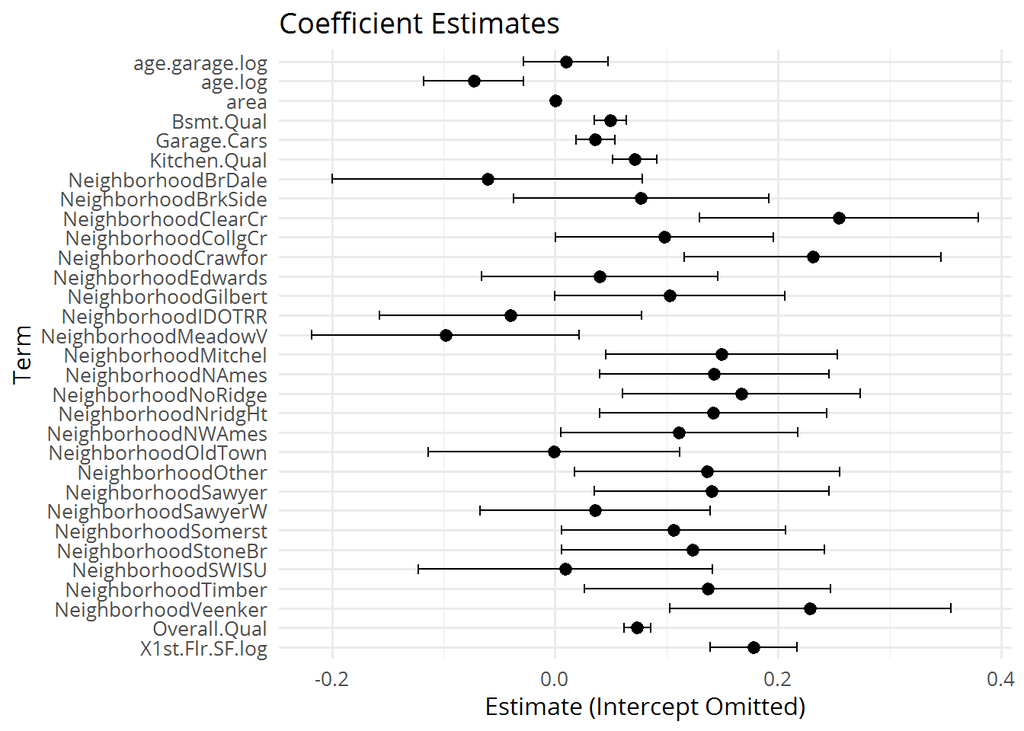

Figure 10: Selected Model Coefficient Plot

As shown in Table 4, this model had an adjusted coefficient of determination of 0.89.

Table 4: Selected Model Summary

|  | r.squared | adj.r.squared | sigma | statistic | p.value | df | logLik | AIC | BIC | deviance | df.residual |
| --- | --- | --- | --- | --- | --- | --- | --- | --- | --- | --- | --- |
| value | 0.8963 | 0.8923 | 0.1253 | 223.6757 | 0 | 32 | 565.0706 | -1064.141 | -908.1755 | 12.5946 | 802 |

### 2.2.3 Section 2.3 Initial Model Residuals

One way to assess the performance of a model is to examine the model’s residuals. In the space below, create a residual plot for your preferred model from above and use it to assess whether your model appears to fit the data well. Comment on any interesting structure in the residual plot (trend, outliers, etc.) and briefly discuss potential implications it may have for your model and inference / prediction you might produce.

The four plots in Figure 11 characterize the model residuals.

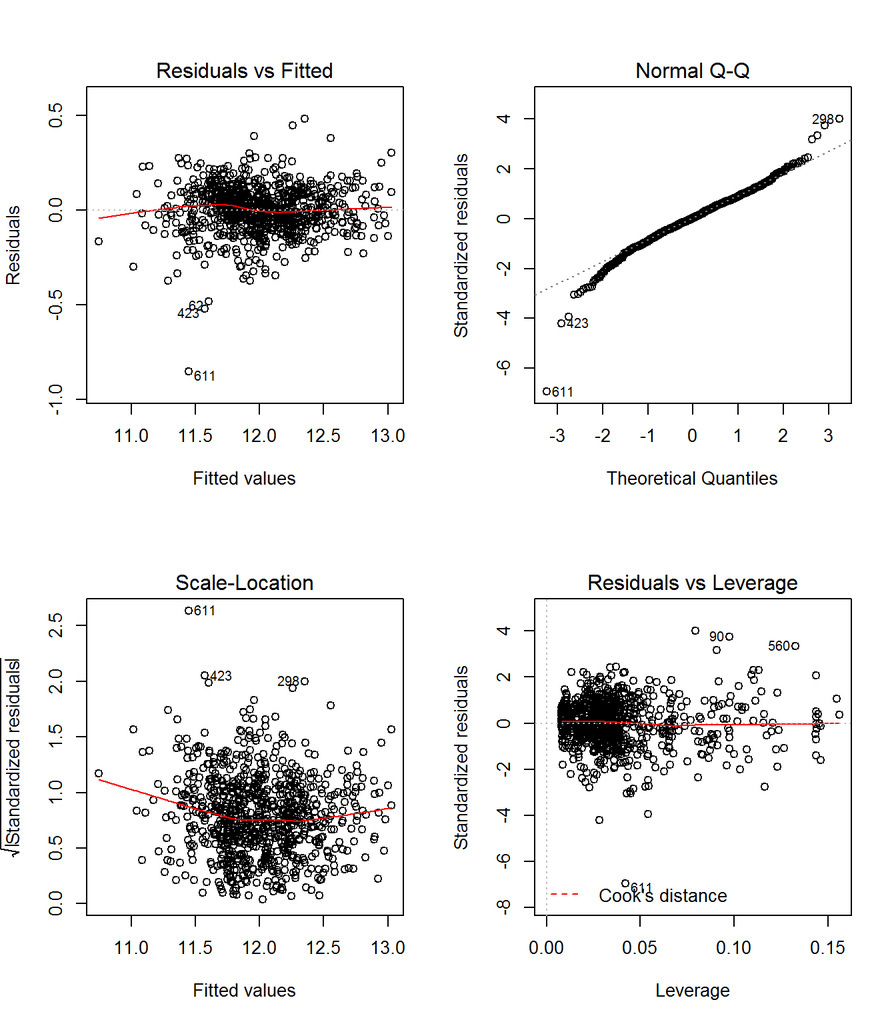

Figure 11: Base Model Residual Plots

An outlier influence analysis was conducted in which the regression equations were fit, with and without the outliers and is summarized in Table 5.

Table 5: Outlier Analysis Summary

| Observation | Adj. R2 With Outlier | Adj. R2 Without Outlier | Percent Change |
| --- | --- | --- | --- |
| 298 | 0.8923 | 0.8938 | 0.1710 |
| 423 | 0.8923 | 0.8939 | 0.1787 |
| 560 | 0.8923 | 0.8937 | 0.1558 |
| 611 | 0.8923 | 0.8971 | 0.5400 |
| 298 423 560 611 | 0.8923 | 0.9019 | 1.0754 |

According to the analysis above, neither of the observations produce any significant change in the proportion of variance explained, nor do they have any pronounced effect on the regression line. Given their lack of influence on the regression equation, there is no justification for their removal.

### 2.2.4 Section 2.4 Initial Model RMSE

You can calculate it directly based on the model output. Be specific about the units of your RMSE (depending on whether you transformed your response variable). The value you report will be more meaningful if it is in the original units (dollars).

### 2.2.5 Section 2.5 Overfitting

The process of building a model generally involves starting with an initial model (as you have done above), identifying its shortcomings, and adapting the model accordingly. This process may be repeated several times until the model fits the data reasonably well. However, the model may do well on training data but perform poorly out-of-sample (meaning, on a dataset other than the original training data) because the model is overly-tuned to specifically fit the training data. This is called “overfitting.” To determine whether overfitting is occurring on a model, compare the performance of a model on both in-sample and out-of-sample data sets. To look at performance of your initial model on out-of-sample data, you will use the data set `ames_test`.

Use your model from above to generate predictions for the housing prices in the test data set. Are the predictions significantly more accurate (compared to the actual sales prices) for the training data than the test data? Why or why not? Briefly explain how you determined that (what steps or processes did you use)?

The out of sample RMSE was 21,880.11, actually a 2.61 percent *improvement* on the in sample performance.

**Note to the learner:** If in real-life practice this out-of-sample analysis shows evidence that the training data fits your model a lot better than the test data, it is probably a good idea to go back and revise the model (usually by simplifying the model) to reduce this overfitting. For simplicity, we do not ask you to do this on the assignment, however.

## 2.3 Part 3 Development of a Final Model

Now that you have developed an initial model to use as a baseline, create a final model with *at most* 20 variables to predict housing prices in Ames, IA, selecting from the full array of variables in the dataset and using any of the tools that we introduced in this specialization.

Carefully document the process that you used to come up with your final model, so that you can answer the questions below.

### 2.3.1 Section 3.1 Final Model

Provide the summary table for your model.

The final model is summarized in Table 6.

Table 6: Final Model Summary

|  | r.squared | adj.r.squared | sigma | statistic | p.value | df | logLik | AIC | BIC | deviance | df.residual |
| --- | --- | --- | --- | --- | --- | --- | --- | --- | --- | --- | --- |
| value | 0.9223 | 0.9146 | 0.1116 | 120.0066 | 0 | 76 | 685.4524 | -1216.905 | -852.9849 | 9.4365 | 758 |

|  | Df | Sum Sq | Mean Sq | F value | Pr(>F) |
| --- | --- | --- | --- | --- | --- |
| Overall.Qual | 1 | 81.8100 | 81.8100 | 6571.5005 | 0.0000 |
| Neighborhood | 23 | 11.6054 | 0.5046 | 40.5312 | 0.0000 |
| area | 1 | 10.7854 | 10.7854 | 866.3528 | 0.0000 |
| Garage.Cars | 1 | 0.9510 | 0.9510 | 76.3877 | 0.0000 |
| Kitchen.Qual | 1 | 1.4220 | 1.4220 | 114.2258 | 0.0000 |
| age.log | 1 | 0.3276 | 0.3276 | 26.3127 | 0.0000 |
| X1st.Flr.SF.log | 1 | 1.2777 | 1.2777 | 102.6295 | 0.0000 |
| Bsmt.Qual | 1 | 0.7080 | 0.7080 | 56.8724 | 0.0000 |
| age.remod | 1 | 0.4183 | 0.4183 | 33.5992 | 0.0000 |
| Fireplace.Qu | 1 | 0.3160 | 0.3160 | 25.3839 | 0.0000 |
| MS.SubClass | 9 | 0.8355 | 0.0928 | 7.4566 | 0.0000 |
| Foundation | 2 | 0.1470 | 0.0735 | 5.9050 | 0.0029 |
| Neighborhood:area | 23 | 1.1629 | 0.0506 | 4.0613 | 0.0000 |
| area:MS.SubClass | 9 | 0.2824 | 0.0314 | 2.5205 | 0.0075 |
| Residuals | 758 | 9.4365 | 0.0124 | NA | NA |

### 2.3.2 Section 3.2 Transformation

Did you decide to transform any variables? Why or why not? Explain in a few sentences.

The univariate and bivariate exploratory data analyses revealed several variables, including the target, with significant right skewed distributions. The following variables in the dataset were log transformed:

- age.log
- age.garage.log
- BsmtFin.SF.2.log
- Enclosed.Porch.log
- Garage.Area.log
- Lot.Area.log
- Low.Qual.Fin.SF.log
- Mas.Vnr.Area.log
- Open.Porch.SF.log
- price.log
- Screen.Porch.log
- Total.Bsmt.SF.log
- TotRms.AbvGrd.log
- Wood.Deck.SF.log
- X1st.Flr.SF.log
- X2nd.Flr.SF.log
- X3Ssn.Porch.log
- Bsmt.Unf.SF.sqrt

The transformation provided nearly normal distributions vis-a-vis the log price.

### 2.3.3 Section 3.3 Variable Interaction

Did you decide to include any variable interactions? Why or why not? Explain in a few sentences.

Interactions 1 and 4 above were included in the final model.

### 2.3.4 Section 3.4 Variable Selection

What method did you use to select the variables you included? Why did you select the method you used? Explain in a few sentences.

Simple linear regression models were calculated during the bivariate exploratory analysis to ascertain the relative importance of each variable from the perspective of proportion of variance explained. Various interactions were similarly tested. Next the terms and interactions with adjusted $R^2$ values above a designated threshold were selected for model evaluation. A grid search was performed adding each term and interaction to the model, one-by-one. Then each of the four selection methods were implemented to create four different models for each set of terms and interactions.

1. Bayes Model Averaging (HPM, MPM, BPM, BMA)
2. Step-wise Forward Selection
3. Step-wise Backward Elimination
4. Step-wise Bidirectional Selection / Elimination

Over 250 such models were computed to ascertain the model with the lowest in-sample and out-of-sample RMSE. Step-wise bidirectional selection / elimination provided the lowest RMSE on the test data.

### 2.3.5 Section 3.5 Model Testing

How did testing the model on out-of-sample data affect whether or how you changed your model? Explain in a few sentences.

The out-of-sample RMSE computed above was the basis by which the final model was chosen.

## 2.4 Part 4 Final Model Assessment

### 2.4.1 Section 4.1 Final Model Residual

For your final model, create and briefly interpret an informative plot of the residuals.

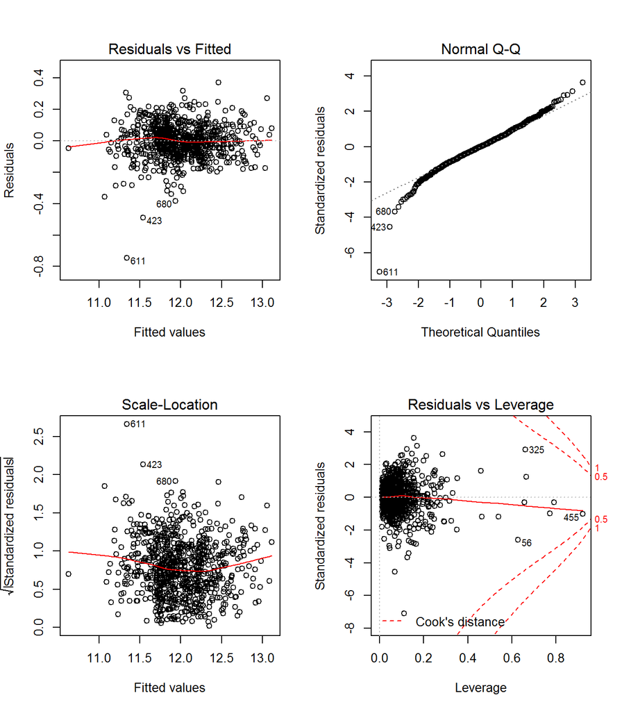

Figure 12: Final Model Residual Plots

A pattern in the Residuals vs Fitted plot would indicate a non-linear relationship between the predictors and the response. The residuals appear to be evenly distributed across the range of predicted values and no pattern suggesting that no non-linear relationship was extant. Three outliers have been identified, but they did not appear to have influence on the regression line or the residuals distribution.

### 2.4.2 Section 4.2 Final Model RMSE

For your final model, calculate and briefly comment on the RMSE.

The final model RMSE measures were 19,311.1 and 23,269 for the training and test sets, respectively. This corresponds to a prediction accuracy on out of sample data of approximately 12.95 percent, relative to the mean home price.

### 2.4.3 Section 4.3 Final Model Evaluation

What are some strengths and weaknesses of your model?

That said, a 12.95% prediction accuracy does leave room for improvement. Given more time, other machine learning techniques such as neural networks, or tree-based models could be evaluated.

### 2.4.4 Section 4.4 Final Model Validation

Testing your final model on a separate, validation data set is a great way to determine how your model will perform in real-life practice.

You will use the “ames_validation” dataset to do some additional assessment of your final model. Discuss your findings, be sure to mention: * What is the RMSE of your final model when applied to the validation data?  
* How does this value compare to that of the training data and/or testing data? * What percentage of the 95% predictive confidence (or credible) intervals contain the true price of the house in the validation data set?  
* From this result, does your final model properly reflect uncertainty?

The final model RMSE on the validation set was $23,086.08, which was within 0.79% of the test RMSE. From an accuracy position, 93.45% of the predictions were inside the 95% prediction interval. Indeed this result reflects the uncertainty of the model predictions.

## 2.5 Part 5 Conclusion

Provide a brief summary of your results, and a brief discussion of what you have learned about the data and your model.

A multiple linear regression was calculated to predict housing prices in Ames Iowa based upon 12 independent variables and two interaction variables. A significant regression equation was found (F(76, 758) = 120.01, p < .05), with an adjusted $R^2$ of 0.915. The RMSE measures were $19,311.06, $23,268.96, and $23,086.08 for the training, test and validation sets, respectively. Approximately 93.45% of the true prices were within the 95% prediction interval.

Several interactions were also noted to have a significant effect on price, notably neighborhood and size, size and subclass, and overall quality and sub class.

With more time, other techniques such as ridge regression/lasso, random forests and neural networks could be applied to improve upon RMSE.